## Homework 2

**This homework is due on Jan. 31, 2017 at 7:00pm. Please submit as a PDF file on Canvas.**

This homework uses data from the `Cars93` data set available in `MASS` package. Each observation in the data frame contains information on passenger cars from 1993. This is a big data frame with 27 columns. We are interested in the information on manufacturer (`Manufacturer`), car model (`Model`), type of car (`Type`), passanger capacity (`Passangers`), midrange price in $1000 (`Price`), maximum horsepower (`Horsepower`), company origin (`Origin`), and fuel tank capacity in gallons (`Fuel.tank.capacity`).

```r
library(MASS)
head(Cars93)
```

```
##   Manufacturer   Model    Type Min.Price Price Max.Price MPG.city
## 1        Acura Integra   Small      12.9  15.9      18.8       25
## 2        Acura  Legend Midsize      29.2  33.9      38.7       18
## 3         Audi      90 Compact      25.9  29.1      32.3       20
## 4         Audi     100 Midsize      30.8  37.7      44.6       19
## 5          BMW    535i Midsize      23.7  30.0      36.2       22
## 6        Buick Century Midsize      14.2  15.7      17.3       22
##   MPG.highway            AirBags DriveTrain Cylinders EngineSize
## 1          31               None      Front         4        1.8
## 2          25 Driver & Passenger      Front         6        3.2
## 3          26        Driver only      Front         6        2.8
## 4          26 Driver & Passenger      Front         6        2.8
## 5          30        Driver only       Rear         4        3.5
## 6          31        Driver only      Front         4        2.2
##   Horsepower  RPM Rev.per.mile Man.trans.avail Fuel.tank.capacity
```

[output cut: 20 more lines]

**Problem 1: (2 pts)** Use ggplot2 to create a scatter plot of the fuel tank capacity versus the car prices. In the same plot, fit a curve to these data using `geom_smooth()`. In one sentence, what broad trend do you observe in fuel tank capacity for different car prices?

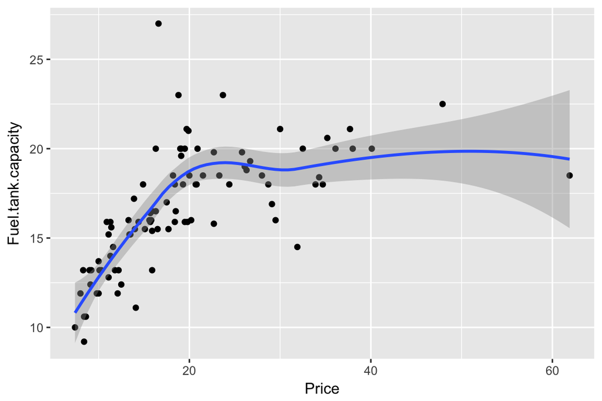

```r
ggplot(Cars93,aes(x=Price, y=Fuel.tank.capacity)) + geom_point() + geom_smooth()
```

Fuel tank capacity increases with price until $20,000, and it levels off after.

**Problem 2: (4 pts)** Next, create a scatter plot of horsepower against car price, facetted by origin. Make two observations about the data from this plot. State each in 1 sentence.

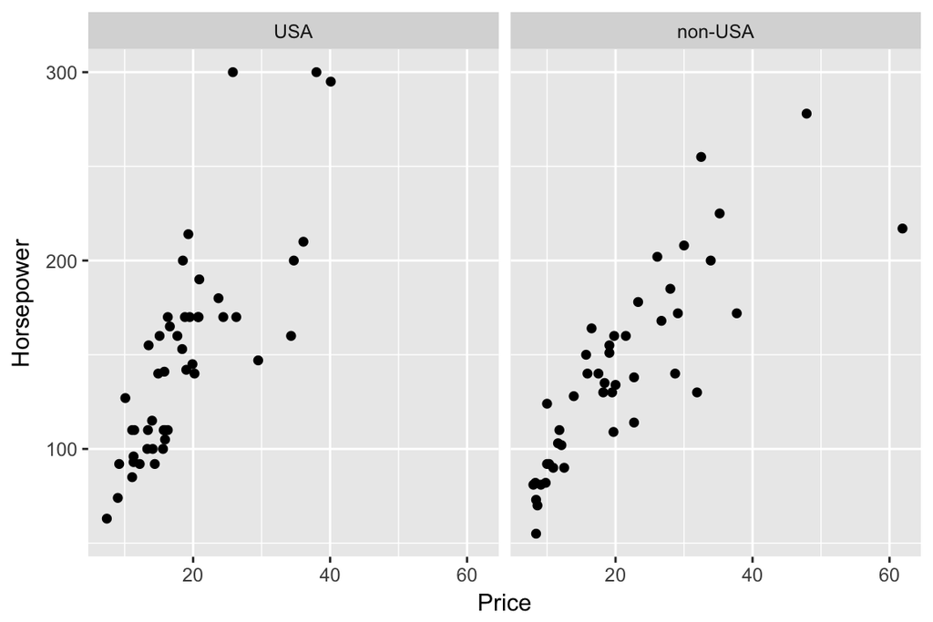

```r
ggplot(Cars93,aes(x=Price, y=Horsepower)) + geom_point() + facet_wrap(~ Origin)
```

Observations:

1. Cars that cost more will generally have more horsepower than cars that cost less.
2. The most expensive cars have non-USA as their origin.
3. Cars that have the most horsepower have USA as their origin.

**Problem 3: (2 pts)** Plot the distribution of price, once using `geom_histogram()` and once using `geom_density()`.

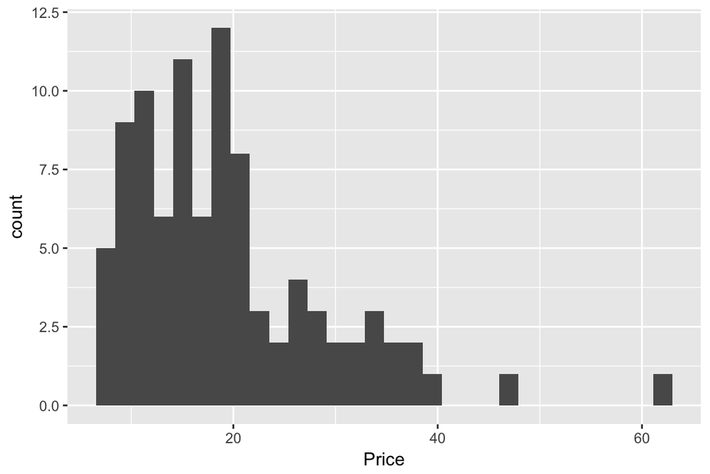

```r
ggplot(Cars93,aes(x=Price))+geom_histogram()
```

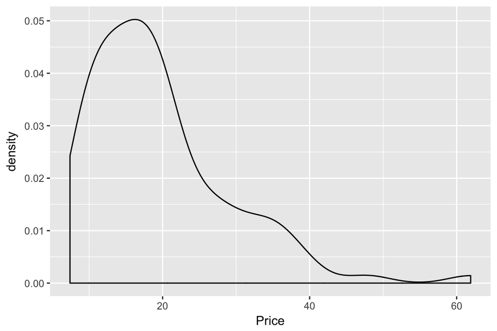

```r
ggplot(Cars93,aes(x=Price))+geom_density()
```

**Problem 4: (2 pts)** What does the y-axis in your histogram represent? In your density plot, what is the *total* area under the curve? Please give a single number as your answer. **HINT**: You do not need to do any additional calculations to determine the area under the curve.

The y-axis in a histogram represents counts in a given range of x-values (bins). The area under the curve of a density plot always sums to 1.